# `PMOIRED` Example 6: global fit of orbital motion, including radial velocities

In this example, we analyse the data from binary HD210763 [Gallenne et al. (2023)](https://ui.adsabs.harvard.edu/abs/2023A%26A...672A.119G/abstract). The goal here is to fit the orbit simultaneously to all data (i.e. all epochs) with one model. For this, we introduce how to use the orbital parameters as model's parameters for `PMOIRED`. We also show how to fit additional data simultaneously to interfereomtric ones, with the help of support functions in hd210763vrad.py, to also fit the radial velocities from the UVES and SOPHIE spectrograph, tabulated in the same paper (table C.1).

Overall, we find very similar results, with a few ceveats:

- we do not take into account the phase error in the field of view which affect the apparent semi-major axis $a$
- we do not account for systematics, for instance due to spectral calibration, which affect the apparent semi-major axis $a$

```python
# -- uncomment to get interactive plots
#%matplotlib widget
import numpy as np
import matplotlib
import matplotlib.pyplot as plt
from astropy import units as U

import pmoired

# where radial velocity are defined, and function to return residuals to the fitimport hd210763vrad
import hd210763vrad
```

## load GRAVITY data, binned

```python
oi = pmoired.OI('/Users/amerand/DATA/Science/HD210763/*fits', insname='GRAVITY_SC', binning=100, verbose=0)

allMJD = []
for d in oi.data:
    allMJD.extend(list(d['MJD']))
print(f"{sorted(allMJD)=}")
print(f"{np.median(allMJD)=}")
```

[output not shown]

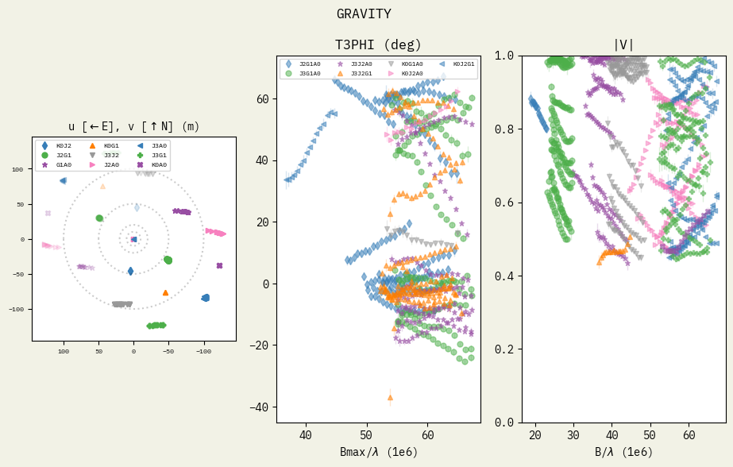

```python
oi.show(obs=['T3PHI', '|V|'])
```

## global fit of interfereomtric data only

The orbital motion is defined by setting the position `2,x` and `2,y` to special keyword `orbit`. By doing so, `PMOIRED` will look to the orbital parmaeters in the form `2,orb ___`, where `___` are:

- `P`: the orbital period in days
- `MJD0`: the modified Julian date of the peri passage
- `e`: the eccentricity
- `incl`: the inclination in degrees
- `omega`: the argument of the periapsis ($\omega$) in degrees
- `OMEGA`: the longitude of the ascending node ($\Omega$) in degrees
- `a`: apparent semi-major axis in mas

Some work is required on the parametrisation:

Comparing our result to [Gallenne et al. (2023)](https://ui.adsabs.harvard.edu/abs/2023A%26A...672A.119G/abstract) table 6 we find an overall good agreement, *except for the definition of $\omega$ and $\Omega$, which are 180º apart!*. The parameters in `PMOIRED` are consistent with [`orbitize!`](https://orbitize.readthedocs.io/en/latest/)

```python
# -- original parameters from Gallenne et al. 2023, table 6, not the -180 in omega and OMEGA
m0 = {'2,ud': 0.1,
     '1,ud': 0.2,
     '2,f': 0.371,
     '2,x': 'orbit',
     '2,y': 'orbit',
     '2,orb P': '$P-42.38 + 42.38',
     'P-42.38': 0.0011,
     '2,orb MJD0': '$MJD0-59800 + 59800',
     'MJD0-59800': 54275.93+42.3811*130-59800,
     '2,orb e': 0.6228,
     '2,orb omega': 293.965-180,
     '2,orb OMEGA': 257.6-180,
     '2,orb incl': 71.0,
     '2,orb gamma': 14.94,
     'additional residuals':hd210763vrad.resi
    }

if False:
    # -- parametrisation using physical quantities -> more correlations
    m0.update({'2,orb M'  : 1.7377+1.4871,
               '2,orb q'  : 1.4871/1.7377,
               '2,orb plx': 10.692,})
else:
    # -- parametrisation using observables -> less correlations
    m0.update({'2,orb Ka': 50.28,
               '2,orb Kb': 58.76,
               '2,orb a' : 3.76,})

def compareParams(bestfit, title='PMOIRED'):
    _best = pmoired.oimodels.computeLambdaParams(bestfit['best'])
    _uncer =  bestfit['uncer'].copy()
    _uncer['2,orb MJD0'] = _uncer['MJD0-59800']
    _uncer['2,orb P'] = _uncer['P-42.38']
    print('parameter       Gallenne+23        '+title)
    for k in m0.keys():
        if not type(m0[k])==str and not type(m0[k])==type(hd210763vrad.resi):
            dif = _best[k]-m0[k]
            if k=='2,orb MJD0':
                # MJD0 is compared modulo the period
                dif = dif%(_best['2,orb P'])
            if _uncer[k]>0:
                dif /= _uncer[k]
                unit = 'sigma'
            else:
                dif = None
            if not dif is None:
                print('%-12s'%k, '%13.6f -> %13.6f ± %11.6f (%5.1f%s)'%(m0[k], _best[k], _uncer[k], dif, unit))
```

```
setupFit> 0/GRAVITY_SC: setting "wl kernel":1.84 according to WL definition
setupFit> 1/GRAVITY_SC: setting "wl kernel":1.84 according to WL definition
setupFit> 2/GRAVITY_SC: setting "wl kernel":1.84 according to WL definition
setupFit> 3/GRAVITY_SC: setting "wl kernel":1.84 according to WL definition
setupFit> 4/GRAVITY_SC: setting "wl kernel":1.84 according to WL definition
setupFit> 5/GRAVITY_SC: setting "wl kernel":1.84 according to WL definition
setupFit> 6/GRAVITY_SC: setting "wl kernel":1.84 according to WL definition
setupFit> 7/GRAVITY_SC: setting "wl kernel":1.84 according to WL definition
setupFit> 8/GRAVITY_SC: setting "wl kernel":1.84 according to WL definition
setupFit> 9/GRAVITY_SC: setting "wl kernel":1.84 according to WL definition
setupFit> 10/GRAVITY_SC: setting "wl kernel":1.84 according to WL definition
[dpfit] 9 FITTED parameters: ['1,ud', '2,f', '2,orb OMEGA', '2,orb a', '2,orb e', '2,orb incl', '2,orb omega', 'MJD0-59800', 'P-42.38']
[dpfit] epsfcn= 1e-06 ftol= 1e-05
[dpfit] using scipy.optimize.leastsq
[dpfit] Both actual and predicted relative reductions in the sum of squares  are at most 0.000010
[dpfit] 31 function calls ( 3.899 ms on average)
# -- degrees of freedom: 1660
# -- reduced chi2: 2.167147507080979
{'1,ud':       0.222, # +/- 0.023
'2,f':        0.37299, # +/- 0.00070
'2,orb OMEGA':77.344, # +/- 0.066
'2,orb a':    3.7432, # +/- 0.0035
'2,orb e':    0.62428, # +/- 0.00091
'2,orb incl': 71.027, # +/- 0.033
'2,orb omega':114.083, # +/- 0.060
'MJD0-59800': -14.549, # +/- 0.012
'P-42.38':    -0.0002, # +/- 0.0016
'2,orb Ka':   50.28,
'2,orb Kb':   58.76,
'2,orb MJD0': '$MJD0-59800 + 59800',
'2,orb P':    '$P-42.38 + 42.38',
'2,orb gamma':14.94,
'2,ud':       0.1,
'2,x':        'orbit',
'2,y':        'orbit',
}

Correlations (%)  >=95 >=90 >=80 >=60 <60%
                0   1   2   3   4   5   6   7   8
 0:       1,ud ### -72  -3  11  -6   4   6   2  -2
 1:        2,f -72 ###  -4 -10  -4  -8   3   5   4
 2:2,orb OMEGA  -3  -4 ###   9  57  -6 -69  10  26
 3:    2,orb a  11 -10   9 ### -15  50 -36 -44 -32
 4:    2,orb e  -6  -4  57 -15 ###  16 -69   7  36
 5: 2,orb incl   4  -8  -6  50  16 ### -25 -37 -22
 6:2,orb omega   6   3 -69 -36 -69 -25 ###  35   4
 7: MJD0-59800   2   5  10 -44   7 -37  35 ###  91
 8:    P-42.38  -2   4  26 -32  36 -22   4  91 ###
parameter       Gallenne+23        PMOIRED interf only (fit)
1,ud              0.200000 ->      0.221761 ±    0.023488 (  0.9sigma)
2,f               0.371000 ->      0.372990 ±    0.000704 (  2.8sigma)
P-42.38           0.001100 ->     -0.000199 ±    0.001640 ( -0.8sigma)
MJD0-59800      -14.527000 ->    -14.549192 ±    0.012347 ( -1.8sigma)
2,orb e           0.622800 ->      0.624280 ±    0.000915 (  1.6sigma)
2,orb omega     113.965000 ->    114.083248 ±    0.060372 (  2.0sigma)
2,orb OMEGA      77.600000 ->     77.343892 ±    0.065551 ( -3.9sigma)
2,orb incl       71.000000 ->     71.026658 ±    0.032845 (  0.8sigma)
2,orb a           3.760000 ->      3.743178 ±    0.003468 ( -4.9sigma)
```

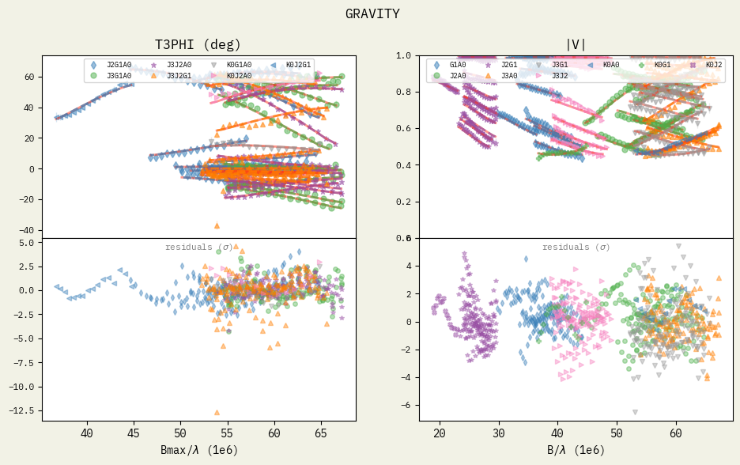

```python
m = m0.copy()
# -- remove radial velocities
m.pop('additional residuals')
# -- these can only be fitted if we have radial velocities
doNotFit=['2,orb Ka', '2,orb Kb', '2,orb plx', '2,orb gamma', '2,orb M', '2,orb q', '2,orb plc']
# -- too small
doNotFit.append('2,ud')

# -- set up context of the fit
oi.setupFit({'obs':['T3PHI', '|V|'],
            'min error':{'T3PHI':1},
            'min relative error':{'|V|':0.01},
            })

oi.doFit(m, doNotFit=doNotFit)
oi.show(showUV=False)

# -- compare with original parameters
compareParams(oi.bestfit,  'PMOIRED interf only (fit)')
```

```
Thu Jun 11 10:28:32 2026: running 100 fits on 12 processes
Thu Jun 11 10:28:47 2026: [████████████████████████████████████████████████████████████]100/100   0s   left
Thu Jun 11 10:28:47 2026: it took 15.5s, 0.15s per fit on average [388.1 fit/minutes]
{'1,ud':       0.225, # +0.044 -0.067
'2,f':        0.3729, # +/- 0.0011
'2,orb OMEGA':77.30, # +/- 0.16
'2,orb a':    3.7438, # +/- 0.0074
'2,orb e':    0.6239, # +/- 0.0019
'2,orb incl': 71.040, # +0.058 -0.074
'2,orb omega':114.089, # +0.157 -0.100
'MJD0-59800': -14.553, # +/- 0.025
'P-42.38':    -0.0012, # +/- 0.0037
'2,orb Ka':   50.28,
'2,orb Kb':   58.76,
'2,orb MJD0': '$MJD0-59800 + 59800',
'2,orb P':    '$P-42.38 + 42.38',
'2,orb gamma':14.94,
'2,ud':       0.1,
'2,x':        'orbit',
'2,y':        'orbit',
}

Correlations (%)  >=95 >=90 >=80 >=60 <60%
                0   1   2   3   4   5   6   7   8
 0:       1,ud ### -68 -25   6 -15  -4  28   5  -6  12
 1:        2,f -68 ###  39  10  13 -13 -29   2   7   0
 2:2,orb OMEGA -25  39 ###  -2  63 -39 -77  19  35 -20
 3:    2,orb a   6  10  -2 ### -33  57 -14 -41 -34   8
 4:    2,orb e -15  13  63 -33 ### -13 -77  18  47 -14
 5: 2,orb incl  -4 -13 -39  57 -13 ###   4 -35 -22   9
 6:2,orb omega  28 -29 -77 -14 -77   4 ###  13 -22  11
 7: MJD0-59800   5   2  19 -41  18 -35  13 ###  90  -1
 8:    P-42.38  -6   7  35 -34  47 -22 -22  90 ###   1
parameter       Gallenne+23        PMOIRED interf only (bootstrapped)
1,ud              0.200000 ->      0.224682 ±    0.055512 (  0.4sigma)
2,f               0.371000 ->      0.372930 ±    0.001087 (  1.8sigma)
P-42.38           0.001100 ->     -0.001211 ±    0.003509 ( -0.7sigma)
MJD0-59800      -14.527000 ->    -14.552648 ±    0.027814 ( -0.9sigma)
2,orb e           0.622800 ->      0.623876 ±    0.001967 (  0.5sigma)
2,orb omega     113.965000 ->    114.088907 ±    0.128575 (  1.0sigma)
2,orb OMEGA      77.600000 ->     77.300266 ±    0.158497 ( -1.9sigma)
2,orb incl       71.000000 ->     71.039865 ±    0.065932 (  0.6sigma)
2,orb a           3.760000 ->      3.743844 ±    0.007620 ( -2.1sigma)
```

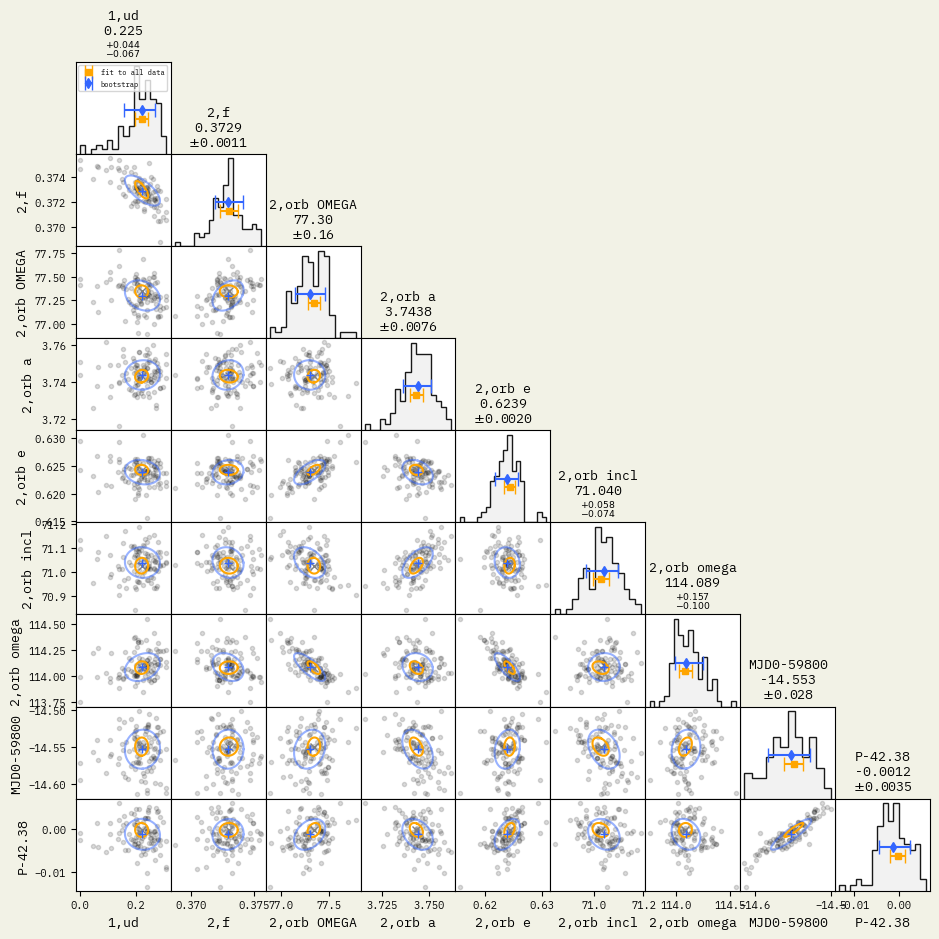

```python
oi.bootstrapFit(100)
oi.showBootstrap()
# -- compare with original parameters
compareParams(oi.boot, 'PMOIRED interf only (bootstrapped)')
```

## Taking into account radial velocities

The orbital calculator can be also used to compute radial velocities, as exploited in oLeo_vrad.py. In that case, we need to parametrise the semi-major axis using the parallax.

Because of Kepler 2rd law, masses, paralaxes and apparent semi-major axis are redundant. We can parametrise using:

- `plx`, `M` and `q`==Msecondary/Mprimary: the parallax in mas, total mass in solar masse and mass ratio.
- `plx`, `Ma` and `Mb`: the parallax in mas and masses of the primary and secondary, in solar masses
- `plx`, `a` and `q`: parallax an apparent semi-major axis in mas, mass ratio.

```
setupFit> 0/GRAVITY_SC: setting "wl kernel":1.84 according to WL definition
setupFit> 1/GRAVITY_SC: setting "wl kernel":1.84 according to WL definition
setupFit> 2/GRAVITY_SC: setting "wl kernel":1.84 according to WL definition
setupFit> 3/GRAVITY_SC: setting "wl kernel":1.84 according to WL definition
setupFit> 4/GRAVITY_SC: setting "wl kernel":1.84 according to WL definition
setupFit> 5/GRAVITY_SC: setting "wl kernel":1.84 according to WL definition
setupFit> 6/GRAVITY_SC: setting "wl kernel":1.84 according to WL definition
setupFit> 7/GRAVITY_SC: setting "wl kernel":1.84 according to WL definition
setupFit> 8/GRAVITY_SC: setting "wl kernel":1.84 according to WL definition
setupFit> 9/GRAVITY_SC: setting "wl kernel":1.84 according to WL definition
setupFit> 10/GRAVITY_SC: setting "wl kernel":1.84 according to WL definition
[dpfit] 12 FITTED parameters: ['1,ud', '2,f', '2,orb Ka', '2,orb Kb', '2,orb OMEGA', '2,orb a', '2,orb e', '2,orb gamma', '2,orb incl', '2,orb omega', 'MJD0-59800', 'P-42.38']
[dpfit] epsfcn= 1e-06 ftol= 1e-05
[dpfit] using scipy.optimize.leastsq
[dpfit] Thu Jun 11 10:28:49 2026 001/000 CHI2: 3.0490e+00|
[dpfit] Both actual and predicted relative reductions in the sum of squares  are at most 0.000010
[dpfit] 27 function calls ( 5.529 ms on average)
# -- degrees of freedom: 1691
# -- reduced chi2: 2.905711311230148
{'1,ud':                0.182, # +/- 0.025
'2,f':                 0.37368, # +/- 0.00069
'2,orb Ka':            50.309, # +/- 0.054
'2,orb Kb':            58.76, # +/- 0.12
'2,orb OMEGA':         77.406, # +/- 0.052
'2,orb a':             3.7464, # +/- 0.0030
'2,orb e':             0.62295, # +/- 0.00052
'2,orb gamma':         14.929, # +/- 0.028
'2,orb incl':          71.003, # +/- 0.030
'2,orb omega':         114.147, # +/- 0.042
'MJD0-59800':          -14.5202, # +/- 0.0028
'P-42.38':             0.00252, # +/- 0.00045
'2,orb MJD0':          '$MJD0-59800 + 59800',
'2,orb P':             '$P-42.38 + 42.38',
'2,ud':                0.1,
'2,x':                 'orbit',
'2,y':                 'orbit',
'additional residuals':<function resi at 0x10fcc09a0>,
}

Correlations (%)  >=95 >=90 >=80 >=60 <60%
```

[output cut: 12 more lines]

```
11:    P-42.38  -6  -2  26  15 -10  11  32  12  20 -13  25 ###
chi2r rad only: 1.1988173490098626
parameter       Gallenne+23        PMOIRED interf only (fit)
1,ud              0.200000 ->      0.182310 ±    0.025066 ( -0.7sigma)
2,f               0.371000 ->      0.373685 ±    0.000686 (  3.9sigma)
P-42.38           0.001100 ->      0.002520 ±    0.000450 (  3.2sigma)
MJD0-59800      -14.527000 ->    -14.520245 ±    0.002787 (  2.4sigma)
2,orb e           0.622800 ->      0.622950 ±    0.000524 (  0.3sigma)
2,orb omega     113.965000 ->    114.147013 ±    0.041728 (  4.4sigma)
2,orb OMEGA      77.600000 ->     77.405839 ±    0.052029 ( -3.7sigma)
2,orb incl       71.000000 ->     71.002505 ±    0.029881 (  0.1sigma)
2,orb gamma      14.940000 ->     14.929302 ±    0.027703 ( -0.4sigma)
2,orb Ka         50.280000 ->     50.308567 ±    0.054041 (  0.5sigma)
2,orb Kb         58.760000 ->     58.762590 ±    0.116158 (  0.0sigma)
2,orb a           3.760000 ->      3.746379 ±    0.002986 ( -4.6sigma)
```

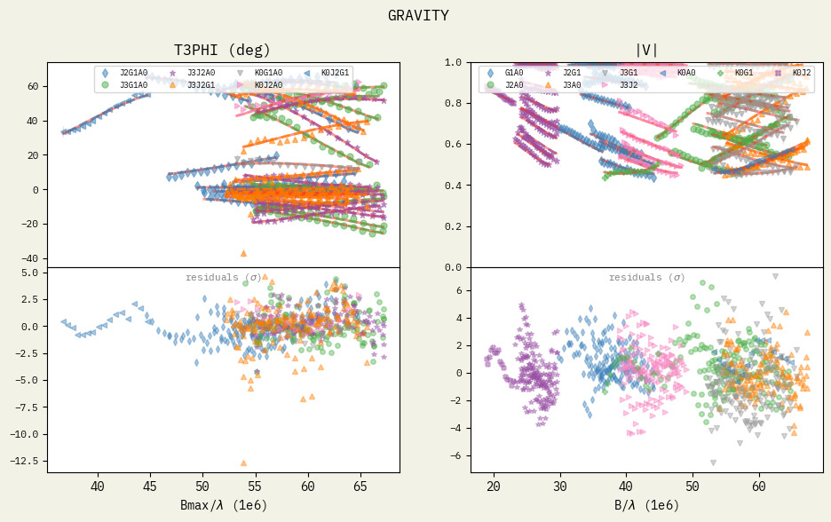

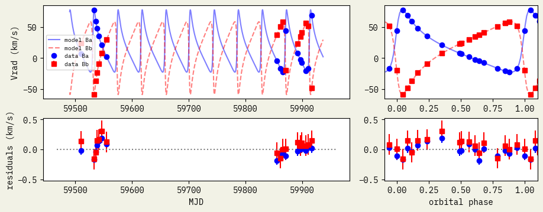

```python
m = m0.copy()
# -- too small
doNotFit=['2,ud']

# -- set up context of the fit
oi.setupFit({'obs':['T3PHI', '|V|'], })

oi.doFit(m, doNotFit=doNotFit)
oi.show(showUV=False)

# -- compare with original parameters
compareParams(oi.bestfit,  'PMOIRED interf only (fit)')
```

## bootstrapping

Radial velocities require also randomisation. `PMOIRED` method `bootstrapFit` accepts an optional function `additionalRandomise` such that `additionalRandomise(True)` will randomise the data, and `additionalRandomise(False)` will reverse the data to their original order and weights. see function `randomise` in hd210763vrad.py.

```
Thu Jun 11 10:28:50 2026: running 300 fits on 12 processes
Thu Jun 11 10:29:25 2026: [████████████████████████████████████████████████████████████]300/300   0s   left
Thu Jun 11 10:29:25 2026: it took 34.8s, 0.12s per fit on average [516.9 fit/minutes]
{'1,ud':                0.179, # +/- 0.057
'2,f':                 0.3737, # +/- 0.0012
'2,orb Ka':            50.314, # +0.086 -0.056
'2,orb Kb':            58.780, # +/- 0.077
'2,orb OMEGA':         77.40, # +/- 0.12
'2,orb a':             3.7471, # +0.0075 -0.0097
'2,orb e':             0.62296, # +/- 0.00089
'2,orb gamma':         14.938, # +/- 0.027
'2,orb incl':          71.006, # +/- 0.070
'2,orb omega':         114.136, # +/- 0.076
'MJD0-59800':          -14.5210, # +0.0037 -0.0166
'P-42.38':             0.00220, # +0.00087 -0.00168
'2,orb MJD0':          '$MJD0-59800 + 59800',
'2,orb P':             '$P-42.38 + 42.38',
'2,ud':                0.1,
'2,x':                 'orbit',
'2,y':                 'orbit',
'additional residuals':<function resi at 0x10fcc09a0>,
}

Correlations (%)  >=95 >=90 >=80 >=60 <60%
                0   1   2   3   4   5   6   7   8   9  10  11
 0:       1,ud ### -53 -10  -5 -32   4 -13  -3  -9  17   7   1 -10
 1:        2,f -53 ###  -2 -10  34   6  -3   4 -12  -8   8   4   3
 2:   2,orb Ka -10  -2 ###  47 -13 -26  73  46  10 -11 -43 -27 -23
 3:   2,orb Kb  -5 -10  47 ### -16 -24  75   2  11 -18 -38 -21 -24
 4:2,orb OMEGA -32  34 -13 -16 ###  40  -5 -11 -18 -65  -4 -13  16
 5:    2,orb a   4   6 -26 -24  40 ### -37   0  54 -59 -14   3  15
 6:    2,orb e -13  -3  73  75  -5 -37 ###  15   3 -20 -39 -29 -29
 7:2,orb gamma  -3   4  46   2 -11   0  15 ###  13  -8 -42 -32 -11
 8: 2,orb incl  -9 -12  10  11 -18  54   3  13 ### -19 -24  -1 -15
 9:2,orb omega  17  -8 -11 -18 -65 -59 -20  -8 -19 ###  52  31   1
10: MJD0-59800   7   8 -43 -38  -4 -14 -39 -42 -24  52 ###  80  18
11:    P-42.38   1   4 -27 -21 -13   3 -29 -32  -1  31  80 ###  15
parameter       Gallenne+23        PMOIRED interf+vrad (bootstrapped)
1,ud              0.200000 ->      0.179272 ±    0.062714 ( -0.3sigma)
2,f               0.371000 ->      0.373746 ±    0.001223 (  2.2sigma)
P-42.38           0.001100 ->      0.002204 ±    0.001276 (  0.9sigma)
MJD0-59800      -14.527000 ->    -14.521035 ±    0.010168 (  0.6sigma)
2,orb e           0.622800 ->      0.622955 ±    0.000882 (  0.2sigma)
2,orb omega     113.965000 ->    114.136111 ±    0.073491 (  2.3sigma)
2,orb OMEGA      77.600000 ->     77.400180 ±    0.128888 ( -1.6sigma)
2,orb incl       71.000000 ->     71.005574 ±    0.066681 (  0.1sigma)
2,orb gamma      14.940000 ->     14.937969 ±    0.027650 ( -0.1sigma)
2,orb Ka         50.280000 ->     50.314310 ±    0.070943 (  0.5sigma)
2,orb Kb         58.760000 ->     58.780124 ±    0.081835 (  0.2sigma)
2,orb a           3.760000 ->      3.747097 ±    0.008589 ( -1.5sigma)
```

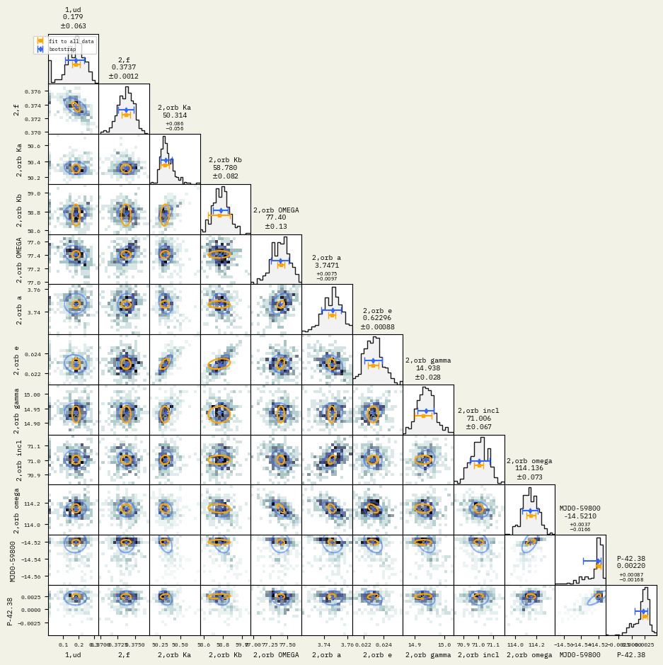

```python
oi.bootstrapFit(300, additionalRandomise=hd210763vrad.randomise)
oi.showBootstrap()
compareParams(oi.boot, 'PMOIRED interf+vrad (bootstrapped)')
```

## grid search orbit

```python
# -- original parameters from Gallenne et al. 2023, table 6, not the -180 in omega and OMEGA
m = {'2,ud': 0.1,
     '1,ud': 0.2,
     '2,f': 0.371,
     '2,x': 'orbit',
     '2,y': 'orbit',
     '2,orb P': '$P-42.38 + 42.38',
     'P-42.38': 0.0011,
     '2,orb MJD0': '$MJD0-59800 + 59800',
     'MJD0-59800': 54275.93+42.3811*130-59800,
     '2,orb e': 0.6228,
     '2,orb omega': 293.965-180,
     '2,orb OMEGA': 257.6-180,
     '2,orb incl': 71.0,
     '2,orb gamma': 14.94,
     '2,orb Ka': 50.28,
     '2,orb Kb': 58.76,
     '2,orb a' : 3.76,
     'additional residuals':hd210763vrad.resi
    }

# -- exploration pattern
expl = {'rand':{'2,orb incl':(30, 150), # >90 to reverse rotation direction
                '2,orb OMEGA':(0, 180),
                '2,orb omega':(-180, 180),
                'MJD0-59800': (-20, 20),
                'P-42.38': (-1, 1),
                 '2,orb Ka':(45, 60), # from max separation, plx and period
                 '2,orb Kb':(45, 60), # from max separation, plx and period
               }}

# -- prior:
prior = [('2,f', '<', 1), # secondary is dimmer
         ('2,orb e', '>=', 0),
         ('2,orb e', '<', 1),
         ('2,orb incl', '>=', 0),
         ('2,orb incl', '<=', 180),
         ('2,orb Ka', '<=', '2,orb Kb'),
        ]

oi.setupFit({'obs':['T3PHI', '|V|']})
doNotFit = ['2,ud']
#oi.doFit(m, doNotFit=doNotFit, prior=prior)

oi.gridFit(expl, Nfits=100, model=m, doNotFit=doNotFit, prior=prior)
```

```
setupFit> 0/GRAVITY_SC: setting "wl kernel":1.84 according to WL definition
setupFit> 1/GRAVITY_SC: setting "wl kernel":1.84 according to WL definition
setupFit> 2/GRAVITY_SC: setting "wl kernel":1.84 according to WL definition
setupFit> 3/GRAVITY_SC: setting "wl kernel":1.84 according to WL definition
setupFit> 4/GRAVITY_SC: setting "wl kernel":1.84 according to WL definition
setupFit> 5/GRAVITY_SC: setting "wl kernel":1.84 according to WL definition
setupFit> 6/GRAVITY_SC: setting "wl kernel":1.84 according to WL definition
setupFit> 7/GRAVITY_SC: setting "wl kernel":1.84 according to WL definition
setupFit> 8/GRAVITY_SC: setting "wl kernel":1.84 according to WL definition
setupFit> 9/GRAVITY_SC: setting "wl kernel":1.84 according to WL definition
setupFit> 10/GRAVITY_SC: setting "wl kernel":1.84 according to WL definition
Thu Jun 11 10:29:27 2026: running 100 fits on 12 processes
Thu Jun 11 10:30:38 2026: [████████████████████████████████████████████████████████████]100/100   0s   left

Thu Jun 11 10:30:38 2026: it took 70.8s, 0.71s per fit on average [84.8 fit/minute]
fits to be taken into account: 93 / 100
  6 did not numerically converge (incl 6 have no uncertainties)
  1 have uncertainties larger than the grid's step[s]
Thu Jun 11 10:30:38 2026: making list of unique minima...
unique minima: 78 / 93 [~1.2 first guesses / minima]
  WARNING!: too many unique minima -> grid too coarse / Nfits too small?  finding the global minimum may be unreliable
Thu Jun 11 10:30:38 2026: linking unique minima to first guess(es)
Thu Jun 11 10:30:38 2026: done
------------
best fit: chi2= 2.8954378830814025
{'1,ud':                0.182, # +/- 0.025
'2,f':                 0.37369, # +/- 0.00068
'2,orb Ka':            50.309, # +/- 0.054
'2,orb Kb':            58.76, # +/- 0.12
'2,orb OMEGA':         77.406, # +/- 0.052
'2,orb a':             3.7464, # +/- 0.0030
'2,orb e':             0.62295, # +/- 0.00052
'2,orb gamma':         14.929, # +/- 0.028
'2,orb incl':          71.003, # +/- 0.030
'2,orb omega':         114.147, # +/- 0.042
'MJD0-59800':          -14.5202, # +/- 0.0028
'P-42.38':             0.00252, # +/- 0.00045
'2,orb MJD0':          '$MJD0-59800 + 59800',
'2,orb P':             '$P-42.38 + 42.38',
'2,ud':                0.1,
'2,x':                 'orbit',
'2,y':                 'orbit',
'additional residuals':<function resi at 0x10fcc09a0>,
}

Correlations (%)  >=95 >=90 >=80 >=60 <60%
                0   1   2   3   4   5   6   7   8   9  10  11
 0:       1,ud ### -69  -2  -1   7  14  -3  -1   6  -1   1  -6
 1:        2,f -69 ###  -2  -1  -7  -8  -4   0  -8   2   3  -2
 2:   2,orb Ka  -2  -2 ###  14  14  -5  49  -2   7 -25  -9  26
 3:   2,orb Kb  -1  -1  14 ###   7  -3  27   3   4 -14  -5  15
 4:2,orb OMEGA   7  -7  14   7 ###  19  35   0  -9 -65 -27 -10
 5:    2,orb a  14  -8  -5  -3  19 ### -12   3  45 -39 -33  11
 6:    2,orb e  -3  -4  49  27  35 -12 ###   2  12 -55 -31  32
 7:2,orb gamma  -1   0  -2   3   0   3   2 ###   2  -3   3  12
 8: 2,orb incl   6  -8   7   4  -9  45  12   2 ###  -9 -17  20
 9:2,orb omega  -1   2 -25 -14 -65 -39 -55  -3  -9 ###  61 -13
10: MJD0-59800   1   3  -9  -5 -27 -33 -31   3 -17  61 ###  25
11:    P-42.38  -6  -2  26  15 -10  11  32  12  20 -13  25 ###
```

```python
# -- show best orbits from the grid
chi2 = sorted([g['chi2'] for g in oi.grid])
chi2min = chi2[0]
print("first 5 solutions' chi2:", np.round(chi2[:5], 1))
deltaChi2 = 1 # shows solution between min(chi2) and min(chi2)+deltaChi2
for g in oi.grid:
    if g['chi2']<chi2min+deltaChi2:
        m = pmoired.oimodels.computeLambdaParams(g['best'])
        orb = {k.split('orb ')[1]:round(m[k], 4) for k in m if k.startswith('2,orb')}
        print('chi2=%.4f'%g['chi2'], '\n > orbit:', orb)
```

```
first 5 solutions' chi2: [ 2.9  2.9  2.9 10.7 13.1]
chi2=2.8954
 > orbit: {'OMEGA': np.float64(77.4058), 'gamma': np.float64(14.9293), 'omega': np.float64(114.147), 'MJD0': 59785.4797, 'incl': np.float64(71.0025), 'Ka': np.float64(50.3086), 'Kb': np.float64(58.7626), 'P': 42.3825, 'a': np.float64(3.7464), 'e': np.float64(0.623)}
chi2=2.8954
 > orbit: {'OMEGA': np.float64(77.4062), 'gamma': np.float64(14.9293), 'omega': np.float64(114.1465), 'MJD0': 59827.8622, 'incl': np.float64(71.0026), 'Ka': np.float64(50.3086), 'Kb': np.float64(58.7626), 'P': 42.3825, 'a': np.float64(3.7464), 'e': np.float64(0.623)}
chi2=2.8955
 > orbit: {'OMEGA': np.float64(77.4078), 'gamma': np.float64(14.9294), 'omega': np.float64(-245.8554), 'MJD0': 59785.4797, 'incl': np.float64(71.0027), 'Ka': np.float64(50.3094), 'Kb': np.float64(58.7635), 'P': 42.3825, 'a': np.float64(3.7464), 'e': np.float64(0.623)}
```